# Interpersonal Results

# Descriptives

### Number of overall effects:

```r
feels %>%
  count()
```

```
## # A tibble: 1 x 1
##       n
##   <int>
## 1   186
```

### Effects per comparison group:

```r
feels %>%
  group_by(pt_comparison) %>%
  count()
```

```
## # A tibble: 4 x 2
## # Groups:   pt_comparison [4]
##   pt_comparison         n
##   <fct>             <int>
## 1 self_v_objective     19
## 2 self_v_control       35
## 3 other_v_objective    62
## 4 other_v_control      70
```

19 is one under our limit of 20, so this will need to be taken as exploratory for the purposes of this preliminary analysis for my prelims. I want to look at these comparisons because they speak to McAuliffe et al’s meta-analytic results.

### Number of samples:

```r
feels %>%
  dplyr::select(sample_number_total) %>%
  unique() %>%
  count()
```

```
## # A tibble: 1 x 1
##       n
##   <int>
## 1    90
```

### Average sample size per cell

**To be used in power analysis**

```r
feels %>%
  dplyr::select(n_pt, n_comparison) %>%
  unique() %>%
  summarise(mean(n_pt),
            mean(n_comparison))
```

```
## # A tibble: 1 x 2
##   `mean(n_pt)` `mean(n_comparison)`
##          <dbl>                <dbl>
## 1         63.9                 62.8
```

# Interpersonal Feelings Results

## Model results

**Contrasts:**

```r
contrasts(feels$pt_comparison)
```

```
##                   self_v_control other_v_objective other_v_control
## self_v_objective               0                 0               0
## self_v_control                 1                 0               0
## other_v_objective              0                 1               0
## other_v_control                0                 0               1
```

### Results nesting outcomes within sample x by scale type

```r
feels$outcome_scale_group <- droplevels(feels$outcome_scale_group)

feels_model <- rma.mv(dunb,
                      var_dunb,
                      mods = ~ pt_comparison,
                      random = list(~ 1 | sample_number_total/outcomes_within_sample_var,
                                    ~ 1 | outcome_scale_group),
                      data = feels)

feels_model
```

```
##
## Multivariate Meta-Analysis Model (k = 186; method: REML)
##
## Variance Components:
##
##             estim    sqrt  nlvls  fixed
## sigma^2.1  0.2987  0.5465     90     no
## sigma^2.2  0.0499  0.2234    132     no
## sigma^2.3  0.0547  0.2339      6     no
##                                                    factor
## sigma^2.1                             sample_number_total
## sigma^2.2  sample_number_total/outcomes_within_sample_var
## sigma^2.3                             outcome_scale_group
##
## Test for Residual Heterogeneity:
## QE(df = 182) = 1016.9094, p-val < .0001
##
## Test of Moderators (coefficients 2:4):
## QM(df = 3) = 33.9357, p-val < .0001
##
## Model Results:
##
##                                 estimate      se     zval    pval    ci.lb
## intrcpt                           0.5042  0.1345   3.7486  0.0002   0.2406
## pt_comparisonself_v_control      -0.2484  0.0752  -3.3022  0.0010  -0.3958
## pt_comparisonother_v_objective    0.0141  0.0677   0.2078  0.8354  -0.1186
## pt_comparisonother_v_control     -0.2422  0.0701  -3.4568  0.0005  -0.3796
##                                   ci.ub
## intrcpt                          0.7678  ***
## pt_comparisonself_v_control     -0.1010  ***
## pt_comparisonother_v_objective   0.1467
## pt_comparisonother_v_control    -0.1049  ***
##
## ---
## Signif. codes:  0 '***' 0.001 '**' 0.01 '*' 0.05 '.' 0.1 ' ' 1
```

### Adding paper as nesting factor

```r
feels_model_auth <- rma.mv(dunb,
                      var_dunb,
                      mods = ~ pt_comparison,
                      random = list(~ 1 | authors/sample_number_total/outcomes_within_sample_var,
                                    ~ 1 | outcome_scale_group),
                      data = feels)

feels_model_auth
```

```
##
## Multivariate Meta-Analysis Model (k = 186; method: REML)
##
## Variance Components:
##
##             estim    sqrt  nlvls  fixed
## sigma^2.1  0.3731  0.6109     50     no
## sigma^2.2  0.0096  0.0978     90     no
## sigma^2.3  0.0501  0.2238    132     no
## sigma^2.4  0.0356  0.1886      6     no
##                                                            factor
## sigma^2.1                                                 authors
## sigma^2.2                             authors/sample_number_total
## sigma^2.3  authors/sample_number_total/outcomes_within_sample_var
## sigma^2.4                                     outcome_scale_group
##
## Test for Residual Heterogeneity:
## QE(df = 182) = 1016.9094, p-val < .0001
##
## Test of Moderators (coefficients 2:4):
## QM(df = 3) = 31.9182, p-val < .0001
##
## Model Results:
##
##                                 estimate      se     zval    pval    ci.lb
## intrcpt                           0.5442  0.1379   3.9462  <.0001   0.2739
## pt_comparisonself_v_control      -0.2293  0.0755  -3.0380  0.0024  -0.3773
## pt_comparisonother_v_objective    0.0143  0.0681   0.2096  0.8340  -0.1193
## pt_comparisonother_v_control     -0.2401  0.0706  -3.4008  0.0007  -0.3785
##                                   ci.ub
## intrcpt                          0.8146  ***
## pt_comparisonself_v_control     -0.0814   **
## pt_comparisonother_v_objective   0.1478
## pt_comparisonother_v_control    -0.1017  ***
##
## ---
## Signif. codes:  0 '***' 0.001 '**' 0.01 '*' 0.05 '.' 0.1 ' ' 1
```

Looking at the sigma’s, it is clear that paper accounts for a large amount of variance and should be included in the model. We will proceed with this model.

The intercept (self vs objective) is significantly different from 0. The simple effects indicate that self v control and other v control lead to significantly lower effect sizes than self v objective. Other v objective did not differ from the intercept.

### Checking if model is over-parametized

```r
# Checking if model is over-parametized
par(mfrow=c(2,2))
profile(feels_model_auth)
```

[output not shown]

Looks good!

### Marginal main effects:

```r
qdrq_feels1 <- qdrg(object = feels_model_auth, data = feels)

emmeans_feels1 <- summary(emmeans(qdrq_feels1, "pt_comparison"))
emmeans_feels1
```

```
##  pt_comparison     emmean    SE  df asymp.LCL asymp.UCL
##  self_v_objective   0.544 0.138 Inf    0.2739     0.815
##  self_v_control     0.315 0.135 Inf    0.0509     0.579
##  other_v_objective  0.559 0.130 Inf    0.3044     0.813
##  other_v_control    0.304 0.130 Inf    0.0485     0.560
##
## Confidence level used: 0.95
```

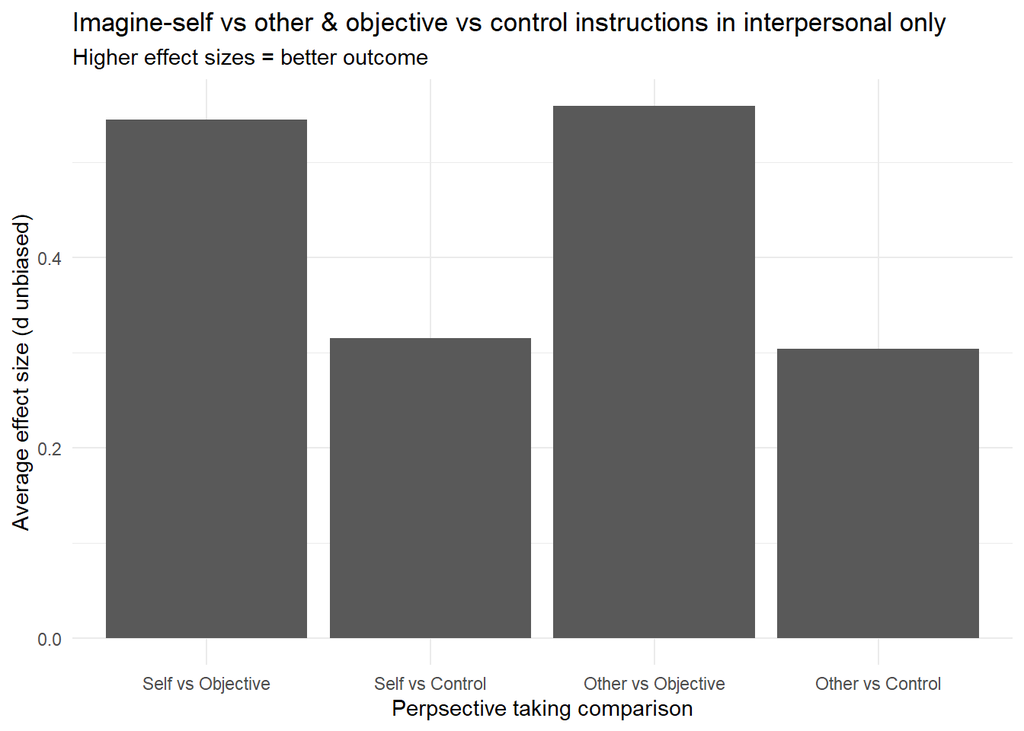

```r
emmeans_feels1 %>% ggplot(aes(x = pt_comparison, y = emmean)) +
  geom_col() +
  theme_minimal() +
  labs(title = "Imagine-self vs other & objective vs control instructions in interpersonal only",
       subtitle = "Higher effect sizes = better outcome",
       x = "Perpsective taking comparison",
       y = "Average effect size (d unbiased)") +
  scale_x_discrete(labels = c('Self vs Objective','Self vs Control',
                              'Other vs Objective', 'Other vs Control'))
```

The marginal main effects indicate that all effect sizes differ from 0. However, both self and other vs objective have medium to large effect sizes, and other and self v control have a small effect size.

## Heterogeneity

### Overall I2 for model

#### Without paper:

```r
get_I2_overall(feels, feels_model)
```

```
## [1] 92.18615
```

High heterogeneity.

#### With paper:

```r
get_I2_overall(feels, feels_model_auth)
```

```
## [1] 93.19782
```

### I2 for levels of variance

*Left value corresponds to top sigma in Variance components output in model results (Sample_number_total). Right-most value corresponds to bottom sigma (Outcome_scale group).*

#### Without paper:

```r
get_I2_levels(feels_model)
```

```
## [1] 68.34 11.42 12.51
```

Most heterogeneity is explained by between-studies variance.

#### With paper:

```r
get_I2_levels(feels_model_auth)
```

```
## [1] 74.31  1.90  9.98  7.08
```

When including paper in the model, most variance is explained by paper.

## Post-hoc power

```r
subgroup_power(n_groups = 4,
               effect_sizes = c(.54, .31, .56, .30),
               sample_size = 124,
               k = 184,
               es_type = "d")
```

```
##
##  Power Analysis for Subgroup analysis:
##
##  Number of Groups:                  4
##  Groups:
##  Expected Effect Sizes:             0.54 0.31 0.56 0.3
##  Expected Sample Size (per group):  62
##  Expected Number of Studies:        184
##
##  Esimated Power to detect subgroup differences
##
##  Fixed-Effects Model:                  1
##  Random-Effects Model (i2 = 0%):       1
##  Random-Effects Model (i2 = 25%):      1
##  Random-Effects Model (i2 = 50%):      0.9999552
##  Random-Effects Model (i2 = 75%):      0.9807107
```

## Forest plot

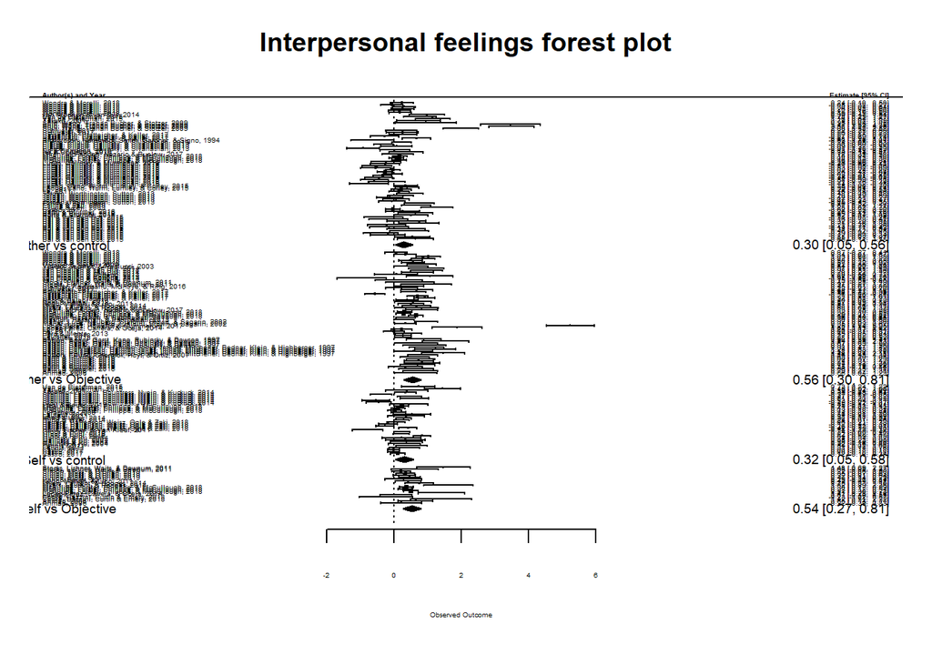

```r
par(mfrow=c(1,1))
forest(feels_model_auth,
       slab = paste(feels$authors,
                    feels$Year, sep = ", "),
       header="Author(s) and Year",
       main = "Interpersonal feelings forest plot",
       ylim = c(-7, 203),
       rows = c(-2:16, 23:57, 64:125, 132:201),
       order = order(feels$pt_comparison),
       addfit=FALSE,
       cex=0.3,
       top = 0)

# self vs obj: 19
# self v control: 35
# other v objective: 62
# other v control: 70

text(x=-9.7, y=-5, labels=c("Self vs Objective"), cex = .6)
addpoly(x = 0.544,
        sei = 0.138,
        ci.lb = 0.2739,
        ci.ub = 0.815,
        rows = -5,
        cex = .6)

text(x=-9.8, y=20, labels=c("Self vs control"), cex = .6)
addpoly(x = 0.315,
        sei = 0.135,
        ci.lb = 0.0509,
        ci.ub = 0.579,
        rows = 20,
        cex = .6)

text(x=-9.7, y=60.5, labels=c("Other vs Objective"), cex = .6)
addpoly(x = 0.559,
        sei = 0.130,
        ci.lb = 0.3044,
        ci.ub = 0.813,
        rows = 60.5,
        cex = .6)

text(x=-9.8, y=129, labels=c("Other vs control"), cex = .6)
addpoly(x = 0.304,
        sei = 0.130,
        ci.lb = 0.0485,
        ci.ub = 0.560,
        rows = 129,
        cex = .6)
```

# Moderator Results

## Scales of measurement

```r
feels %>%
  group_by(outcome_scale_group) %>%
  count()
```

```
## # A tibble: 6 x 2
## # Groups:   outcome_scale_group [6]
##   outcome_scale_group     n
##   <fct>               <int>
## 1 10                     66
## 2 11                     37
## 3 13                     13
## 4 14                     50
## 5 15                     19
## 6 16                      1
```

```r
feels_mod <- feels %>%
  filter(outcome_scale_group != 16) %>%
  unique() #removing this level since there is only one study in it

feels_mod$outcome_scale_group <- droplevels(feels_mod$outcome_scale_group)

#model with interaction
feels_model_mod1 <- rma.mv(dunb,
                      var_dunb,
                      mods = ~ pt_comparison*outcome_scale_group,
                      random = list(~ 1 | authors/sample_number_total/outcomes_within_sample_var),
                      data = feels_mod)

feels_model_mod1
```

```
##
## Multivariate Meta-Analysis Model (k = 185; method: REML)
##
## Variance Components:
##
##             estim    sqrt  nlvls  fixed
## sigma^2.1  0.3810  0.6173     50     no
## sigma^2.2  0.0000  0.0000     90     no
## sigma^2.3  0.0639  0.2528    131     no
##                                                            factor
## sigma^2.1                                                 authors
## sigma^2.2                             authors/sample_number_total
## sigma^2.3  authors/sample_number_total/outcomes_within_sample_var
##
## Test for Residual Heterogeneity:
## QE(df = 169) = 828.8731, p-val < .0001
##
## Test of Moderators (coefficients 2:16):
## QM(df = 15) = 79.0033, p-val < .0001
##
## Model Results:
##
##                                                       estimate      se     zval
## intrcpt                                                 0.8825  0.1360   6.4868
## pt_comparisonself_v_control                            -0.3484  0.1190  -2.9289
## pt_comparisonother_v_objective                          0.0269  0.0979   0.2749
## pt_comparisonother_v_control                           -0.3650  0.1078  -3.3855
## outcome_scale_group11                                  -0.6914  0.3592  -1.9250
## outcome_scale_group13                                  -0.2803  0.2155  -1.3006
## outcome_scale_group14                                  -0.3270  0.1555  -2.1025
## outcome_scale_group15                                  -0.1093  0.2051  -0.5330
## pt_comparisonself_v_control:outcome_scale_group11       0.4284  0.3529   1.2138
## pt_comparisonother_v_objective:outcome_scale_group11    0.0505  0.3768   0.1341
## pt_comparisonother_v_control:outcome_scale_group11      0.5660  0.3825   1.4798
## pt_comparisonother_v_objective:outcome_scale_group13   -0.3631  0.5296  -0.6856
## pt_comparisonself_v_control:outcome_scale_group14       0.1547  0.1539   1.0055
## pt_comparisonother_v_objective:outcome_scale_group14   -0.0204  0.1356  -0.1505
## pt_comparisonother_v_control:outcome_scale_group14      0.1386  0.1433   0.9671
## pt_comparisonself_v_control:outcome_scale_group15      -0.6148  0.2701  -2.2764
##                                                         pval    ci.lb    ci.ub
```

[output cut: 21 more lines]

```
## outcome_scale_group11                                   .
## outcome_scale_group13
## outcome_scale_group14                                   *
## outcome_scale_group15
## pt_comparisonself_v_control:outcome_scale_group11
## pt_comparisonother_v_objective:outcome_scale_group11
## pt_comparisonother_v_control:outcome_scale_group11
## pt_comparisonother_v_objective:outcome_scale_group13
## pt_comparisonself_v_control:outcome_scale_group14
## pt_comparisonother_v_objective:outcome_scale_group14
## pt_comparisonother_v_control:outcome_scale_group14
## pt_comparisonself_v_control:outcome_scale_group15       *
##
## ---
## Signif. codes:  0 '***' 0.001 '**' 0.01 '*' 0.05 '.' 0.1 ' ' 1
```

Scale group 10 (Empathy) is the reference group. Dropped scale group 16 since there was only one study in it. The analysis dropped redundant comparisons that have 0 studies per cell. There was one significant interaction - Self v control:outcome scale group 15 (negative emotions; was reverse coded already).

### Heterogeneity

#### I2 overall

```r
get_I2_overall(feels_mod, feels_model_mod1)
```

```
## [1] 92.61201
```

#### I2 for levels of variance

*Left value corresponds to top sigma in Variance components output in model results (Sample_number_total). Right-most value corresponds to bottom sigma (Outcome_scale group).*

```r
get_I2_levels(feels_model_mod1)
```

```
## [1] 79.59  0.00 13.35
```

Most heterogeneity is explained by between-study variance, followed by between-outcomes variance.

## Target - amount of information

```r
feels_model_mod2 <- rma.mv(dunb,
                      var_dunb,
                      mods = ~ pt_comparison*target_information,
                      random = list(~ 1 | authors/sample_number_total/outcomes_within_sample_var,
                                    ~ 1 | outcome_scale_group),
                      data = feels_mod)

feels_model_mod2
```

```
##
## Multivariate Meta-Analysis Model (k = 185; method: REML)
##
## Variance Components:
##
##             estim    sqrt  nlvls  fixed
## sigma^2.1  0.4171  0.6458     50     no
## sigma^2.2  0.0061  0.0779     90     no
## sigma^2.3  0.0513  0.2266    131     no
## sigma^2.4  0.0411  0.2026      5     no
##                                                            factor
## sigma^2.1                                                 authors
## sigma^2.2                             authors/sample_number_total
## sigma^2.3  authors/sample_number_total/outcomes_within_sample_var
## sigma^2.4                                     outcome_scale_group
##
## Test for Residual Heterogeneity:
## QE(df = 174) = 987.9156, p-val < .0001
##
## Test of Moderators (coefficients 2:11):
## QM(df = 10) = 39.6625, p-val < .0001
##
## Model Results:
##
##                                                     estimate      se     zval
## intrcpt                                               0.3410  0.2683   1.2712
## pt_comparisonself_v_control                           0.0442  0.5458   0.0809
## pt_comparisonother_v_objective                        0.2252  0.2399   0.9384
## pt_comparisonother_v_control                         -0.0078  0.1824  -0.0426
## target_information2                                   0.2567  0.2695   0.9524
## target_information3                                   0.0301  0.2133   0.1411
## pt_comparisonself_v_control:target_information2      -0.2972  0.5517  -0.5387
## pt_comparisonother_v_objective:target_information2   -0.1800  0.2513  -0.7161
## pt_comparisonother_v_control:target_information2     -0.2811  0.1968  -1.4285
## pt_comparisonself_v_control:target_information3      -0.1299  0.5784  -0.2246
## pt_comparisonother_v_objective:target_information3   -0.2234  0.1908  -1.1710
##                                                       pval    ci.lb   ci.ub
## intrcpt                                             0.2037  -0.1848  0.8668
## pt_comparisonself_v_control                         0.9355  -1.0255  1.1139
## pt_comparisonother_v_objective                      0.3480  -0.2451  0.6954
## pt_comparisonother_v_control                        0.9660  -0.3653  0.3498
## target_information2                                 0.3409  -0.2715  0.7849
## target_information3                                 0.8878  -0.3880  0.4482
## pt_comparisonself_v_control:target_information2     0.5901  -1.3786  0.7842
## pt_comparisonother_v_objective:target_information2  0.4739  -0.6725  0.3126
## pt_comparisonother_v_control:target_information2    0.1531  -0.6669  0.1046
## pt_comparisonself_v_control:target_information3     0.8223  -1.2635  1.0038
## pt_comparisonother_v_objective:target_information3  0.2416  -0.5973  0.1505
##
## ---
## Signif. codes:  0 '***' 0.001 '**' 0.01 '*' 0.05 '.' 0.1 ' ' 1
```

None are significant. Emmeans won’t work because redundant predictors were dropped from rma.mv model.

### Heterogeneity

#### I2 overall

```r
get_I2_overall(feels_mod, feels_model_mod2)
```

```
## [1] 93.74325
```

High heterogeneity - moderator did not help.

#### I2 for levels of variance

*Left value corresponds to top sigma in Variance components output in model results (Sample_number_total). Right-most value corresponds to bottom sigma (Outcome_scale group).*

```r
get_I2_levels(feels_model_mod2)
```

```
## [1] 75.93  1.11  9.35  7.47
```

## Target - In need/In distress target grouping (relevant to outcome category)

```r
need_distress_data <- feels_mod %>%
  na.omit()

feels_model_mod3 <- rma.mv(dunb,
                      var_dunb,
                      mods = ~ pt_comparison*target_emapthetic_need,
                      random = list(~ 1 | authors/sample_number_total/outcomes_within_sample_var,
                                    ~ 1 | outcome_scale_group),
                      data = need_distress_data)

feels_model_mod3
```

```
##
## Multivariate Meta-Analysis Model (k = 50; method: REML)
##
## Variance Components:
##
##             estim    sqrt  nlvls  fixed
## sigma^2.1  1.7615  1.3272     17     no
## sigma^2.2  0.0000  0.0000     30     no
## sigma^2.3  0.0734  0.2710     38     no
## sigma^2.4  0.0212  0.1458      5     no
##                                                            factor
## sigma^2.1                                                 authors
## sigma^2.2                             authors/sample_number_total
## sigma^2.3  authors/sample_number_total/outcomes_within_sample_var
## sigma^2.4                                     outcome_scale_group
##
## Test for Residual Heterogeneity:
## QE(df = 42) = 559.1405, p-val < .0001
##
## Test of Moderators (coefficients 2:8):
## QM(df = 7) = 3.5446, p-val = 0.8305
##
## Model Results:
##
##                                                         estimate      se
## intrcpt                                                   0.2688  1.3495
## pt_comparisonself_v_control                               0.9600  1.4807
## pt_comparisonother_v_objective                            0.2442  1.5117
## pt_comparisonother_v_control                             -0.0169  1.5613
## target_emapthetic_need2                                   0.9480  1.4439
## pt_comparisonself_v_control:target_emapthetic_need2      -1.3595  1.4920
## pt_comparisonother_v_objective:target_emapthetic_need2   -0.2688  1.5194
## pt_comparisonother_v_control:target_emapthetic_need2     -0.3373  1.6018
##                                                            zval    pval
## intrcpt                                                  0.1992  0.8421
## pt_comparisonself_v_control                              0.6484  0.5168
## pt_comparisonother_v_objective                           0.1615  0.8717
## pt_comparisonother_v_control                            -0.0108  0.9914
## target_emapthetic_need2                                  0.6565  0.5115
## pt_comparisonself_v_control:target_emapthetic_need2     -0.9112  0.3622
## pt_comparisonother_v_objective:target_emapthetic_need2  -0.1769  0.8596
## pt_comparisonother_v_control:target_emapthetic_need2    -0.2106  0.8332
##                                                           ci.lb   ci.ub
## intrcpt                                                 -2.3761  2.9137
## pt_comparisonself_v_control                             -1.9421  3.8621
## pt_comparisonother_v_objective                          -2.7188  3.2071
## pt_comparisonother_v_control                            -3.0769  3.0432
## target_emapthetic_need2                                 -1.8821  3.7780
## pt_comparisonself_v_control:target_emapthetic_need2     -4.2837  1.5647
## pt_comparisonother_v_objective:target_emapthetic_need2  -3.2469  2.7092
## pt_comparisonother_v_control:target_emapthetic_need2    -3.4767  2.8022
##
## ---
## Signif. codes:  0 '***' 0.001 '**' 0.01 '*' 0.05 '.' 0.1 ' ' 1
```

### Marginal main effects

```r
qdrq_feels3 <- qdrg(object = feels_model_mod3, data = need_distress_data)

emmeans_feels3 <- summary(emmeans(qdrq_feels3, "pt_comparison", "target_emapthetic_need"))
emmeans_feels3
```

```
## target_emapthetic_need = 1:
##  pt_comparison     emmean    SE  df asymp.LCL asymp.UCL
##  self_v_objective   0.269 1.349 Inf   -2.3761      2.91
##  self_v_control     1.229 0.608 Inf    0.0380      2.42
##  other_v_objective  0.513 0.687 Inf   -0.8325      1.86
##  other_v_control    0.252 0.786 Inf   -1.2892      1.79
##
## target_emapthetic_need = 2:
##  pt_comparison     emmean    SE  df asymp.LCL asymp.UCL
##  self_v_objective   1.217 0.516 Inf    0.2061      2.23
##  self_v_control     0.817 0.477 Inf   -0.1183      1.75
##  other_v_objective  1.192 0.507 Inf    0.1982      2.19
##  other_v_control    0.863 0.476 Inf   -0.0703      1.80
##
## Confidence level used: 0.95
```

### Heterogeneity

#### I2 overall

```r
get_I2_overall(need_distress_data, feels_model_mod3)
```

```
## [1] 98.38878
```

High heterogeneity

#### I2 for levels of variance

*Left value corresponds to top sigma in Variance components output in model results (Sample_number_total). Right-most value corresponds to bottom sigma (Outcome_scale group).*

```r
get_I2_levels(feels_model_mod3)
```

```
## [1] 93.47  0.00  3.90  1.13
```

## Sample size

```r
feels_model_mod4 <- rma.mv(dunb,
                      var_dunb,
                      mods = ~ pt_comparison*n_overall,
                      random = list(~ 1 | authors/sample_number_total/outcomes_within_sample_var,
                                    ~ 1 | outcome_scale_group),
                      data = feels_mod)

feels_model_mod4
```

```
##
## Multivariate Meta-Analysis Model (k = 185; method: REML)
##
## Variance Components:
##
##             estim    sqrt  nlvls  fixed
## sigma^2.1  0.3891  0.6238     50     no
## sigma^2.2  0.0095  0.0973     90     no
## sigma^2.3  0.0510  0.2258    131     no
## sigma^2.4  0.0392  0.1980      5     no
##                                                            factor
## sigma^2.1                                                 authors
## sigma^2.2                             authors/sample_number_total
## sigma^2.3  authors/sample_number_total/outcomes_within_sample_var
## sigma^2.4                                     outcome_scale_group
##
## Test for Residual Heterogeneity:
## QE(df = 177) = 967.9190, p-val < .0001
##
## Test of Moderators (coefficients 2:8):
## QM(df = 7) = 32.4668, p-val < .0001
##
## Model Results:
##
##                                           estimate      se     zval    pval
## intrcpt                                     0.4410  0.2042   2.1594  0.0308
## pt_comparisonself_v_control                -0.0774  0.2163  -0.3580  0.7203
## pt_comparisonother_v_objective              0.0693  0.1504   0.4607  0.6450
## pt_comparisonother_v_control               -0.1660  0.1725  -0.9623  0.3359
## n_overall                                   0.0004  0.0008   0.5346  0.5930
## pt_comparisonself_v_control:n_overall      -0.0005  0.0007  -0.7498  0.4534
## pt_comparisonother_v_objective:n_overall   -0.0002  0.0005  -0.3374  0.7358
## pt_comparisonother_v_control:n_overall     -0.0003  0.0006  -0.4247  0.6711
##                                             ci.lb   ci.ub
## intrcpt                                    0.0407  0.8413  *
## pt_comparisonself_v_control               -0.5014  0.3465
## pt_comparisonother_v_objective            -0.2256  0.3642
## pt_comparisonother_v_control              -0.5040  0.1721
## n_overall                                 -0.0012  0.0020
## pt_comparisonself_v_control:n_overall     -0.0018  0.0008
## pt_comparisonother_v_objective:n_overall  -0.0012  0.0009
## pt_comparisonother_v_control:n_overall    -0.0014  0.0009
##
## ---
## Signif. codes:  0 '***' 0.001 '**' 0.01 '*' 0.05 '.' 0.1 ' ' 1
```

Intercept different from 0. No interaction with sample size.

### Heterogeneity

#### I2 overall

```r
get_I2_overall(feels_mod, feels_model_mod4)
```

```
## [1] 93.32702
```

#### I2 for levels of variance

*Left value corresponds to top sigma in Variance components output in model results (Sample_number_total). Right-most value corresponds to bottom sigma (Outcome_scale group).*

```r
get_I2_levels(feels_model_mod4)
```

```
## [1] 74.46  1.81  9.76  7.50
```

# Publication Bias - Egger’s Test

```r
# Getting modified covariate that removes artifactual correlation between SMD ES and its related variance
eggers_data_feels <- feels %>%
    mutate(Va = 4/(n_overall),
         sda = sqrt(Va),
         sdi = sqrt(var_dunb))

# Adapted from Rodgers & Putjevosky (2019) https://osf.io/7ak2m/?view_only=e74f9ddad3834e0e8c0bae9ef6b0441c

mlma_egg_mod_sda_feels <- rma.mv(dunb ~ 1 + sda,
                           V = var_dunb,
                           random = list(~ 1 | authors/sample_number_total/outcomes_within_sample_var,
                                    ~ 1 | outcome_scale_group),
                           data = eggers_data_feels, test = "t")


mlma_egg_mod_se_feels <- rma.mv(dunb ~ 1 + sdi,
                           V = var_dunb,
                           random = list(~ 1 | authors/sample_number_total/outcomes_within_sample_var,
                                    ~ 1 | outcome_scale_group),
                           data = eggers_data_feels, test = "t")


mlma_results_sda_feels <- with(mlma_egg_mod_sda_feels,
                                 data.frame(Egger_test = "Modified Covariate",
                                                      beta = b[2],
                                                      se = se[2],
                                                      p_val = pt(zval[2], dfs, lower.tail = FALSE))) #this is the t-value

mlma_results_se_feels <- with(mlma_egg_mod_se_feels,
                                data.frame(Egger_test = "Standard Error",
                                                    beta = b[2],
                                                    se = se[2],
                                                    p_val = pt(zval[2], dfs, lower.tail = FALSE))) #this is the t-value

egger_feels_results <- rbind(mlma_results_sda_feels, mlma_results_se_feels)
egger_feels_results
```

```
##           Egger_test      beta        se        p_val
## 1 Modified Covariate -1.106680 0.8986228 0.8901515340
## 2     Standard Error  2.521766 0.7933578 0.0008681685
```

# Checking sub-sample heterogeneity

```r
feels %>%
  mutate(outcome_scale_group = dplyr::recode(outcome_scale_group,
                                             `10` = "empathic emotions",
                                             `11` = "helping behavior",
                                             `13` = "harmful behavior",
                                             `14` = "Other pos/sympathetic emotions",
                                             `15` = "Negative emotions directed toward target",
                                             `16` = "Perceptions of perspective taker")) %>%   # CHECK harmful behavior AND negative emotions are REVERSE CODED
  count(outcome_scale_group)
```

```
## # A tibble: 6 x 2
##   outcome_scale_group                          n
## * <fct>                                    <int>
## 1 empathic emotions                           66
## 2 helping behavior                            37
## 3 harmful behavior                            13
## 4 Other pos/sympathetic emotions              50
## 5 Negative emotions directed toward target    19
## 6 Perceptions of perspective taker             1
```

Cell with most effect sizes is empathic empotions (emapthy, empathic concern).

### Within empathic emotions and each comparison, the cells become uneven.

```r
feels %>%
  filter(outcome_scale_group == 10) %>%
  group_by(pt_comparison) %>%
  count()
```

```
## # A tibble: 4 x 2
## # Groups:   pt_comparison [4]
##   pt_comparison         n
##   <fct>             <int>
## 1 self_v_objective      9
## 2 self_v_control        8
## 3 other_v_objective    33
## 4 other_v_control      16
```

## Meta sub-example w/ pt as moderator

```r
heterotest1_feels <- feels %>%
  filter(outcome_scale_group == 10)

heterotest1_feels$outcome_scale_group <- droplevels(heterotest1_feels$outcome_scale_group)

feels_model_heterotest1 <- rma.mv(dunb,
                      var_dunb,
                      mods = ~ pt_comparison,
                      random = list(~ 1 | authors/sample_number_total/outcomes_within_sample_var), data = heterotest1_feels)

feels_model_heterotest1
```

```
##
## Multivariate Meta-Analysis Model (k = 66; method: REML)
##
## Variance Components:
##
##             estim    sqrt  nlvls  fixed
## sigma^2.1  0.7263  0.8523     31     no
## sigma^2.2  0.0188  0.1371     47     no
## sigma^2.3  0.0188  0.1371     47     no
##                                                            factor
## sigma^2.1                                                 authors
## sigma^2.2                             authors/sample_number_total
## sigma^2.3  authors/sample_number_total/outcomes_within_sample_var
##
## Test for Residual Heterogeneity:
## QE(df = 62) = 512.5265, p-val < .0001
##
## Test of Moderators (coefficients 2:4):
## QM(df = 3) = 33.9786, p-val < .0001
##
## Model Results:
##
##                                 estimate      se     zval    pval    ci.lb
## intrcpt                           1.0001  0.1803   5.5474  <.0001   0.6467
## pt_comparisonself_v_control      -0.3916  0.1228  -3.1886  0.0014  -0.6323
## pt_comparisonother_v_objective    0.0626  0.0994   0.6292  0.5292  -0.1323
## pt_comparisonother_v_control     -0.3704  0.1097  -3.3759  0.0007  -0.5855
##                                   ci.ub
## intrcpt                          1.3534  ***
## pt_comparisonself_v_control     -0.1509   **
## pt_comparisonother_v_objective   0.2574
## pt_comparisonother_v_control    -0.1554  ***
##
## ---
## Signif. codes:  0 '***' 0.001 '**' 0.01 '*' 0.05 '.' 0.1 ' ' 1
```

### Heterogeneity

#### Overall

```r
get_I2_overall(heterotest1_feels, feels_model_heterotest1)
```

```
## [1] 95.20211
```

#### Levels

```r
get_I2_levels(feels_model_heterotest1)
```

```
## [1] 90.71  2.35  2.35
```

### Post-hoc power

```r
heterotest1_feels %>%
  dplyr::select(n_pt, n_comparison) %>%
  unique() %>%
  summarise(mean(n_pt),
            mean(n_comparison))
```

```
## # A tibble: 1 x 2
##   `mean(n_pt)` `mean(n_comparison)`
##          <dbl>                <dbl>
## 1         67.2                 66.5
```

**Rounded up on sample size because “sample size must be a multiple of n_groups.”**

```r
subgroup_power(n_groups = 4,
               effect_sizes = c(1.03, -.39, .07, -.37),
               sample_size = 68,
               k = 66,
               es_type = "d")
```

```
##
##  Power Analysis for Subgroup analysis:
##
##  Number of Groups:                  4
##  Groups:
##  Expected Effect Sizes:             1.03 -0.39 0.07 -0.37
##  Expected Sample Size (per group):  34
##  Expected Number of Studies:        66
##
##  Esimated Power to detect subgroup differences
##
##  Fixed-Effects Model:                  1
##  Random-Effects Model (i2 = 0%):       1
##  Random-Effects Model (i2 = 25%):      1
##  Random-Effects Model (i2 = 50%):      1
##  Random-Effects Model (i2 = 75%):      1
```

## Meta sub-example w/ one pt condition

** Using “other_v_objective” because it had most effect sizes per cell.**

```r
heterotest2_feels <- heterotest1_feels %>%
  filter(pt_comparison == "other_v_objective")

feels_model_heterotest2 <- rma.mv(dunb,
                      var_dunb,
                      random = list(~ 1 | authors/sample_number_total/outcomes_within_sample_var), data = heterotest2_feels)

feels_model_heterotest2
```

```
##
## Multivariate Meta-Analysis Model (k = 33; method: REML)
##
## Variance Components:
##
##             estim    sqrt  nlvls  fixed
## sigma^2.1  0.8147  0.9026     22     no
## sigma^2.2  0.0051  0.0713     33     no
## sigma^2.3  0.0051  0.0713     33     no
##                                                            factor
## sigma^2.1                                                 authors
## sigma^2.2                             authors/sample_number_total
## sigma^2.3  authors/sample_number_total/outcomes_within_sample_var
##
## Test for Heterogeneity:
## Q(df = 32) = 219.4243, p-val < .0001
##
## Model Results:
##
## estimate      se    zval    pval   ci.lb   ci.ub
##   0.9623  0.1990  4.8348  <.0001  0.5722  1.3524  ***
##
## ---
## Signif. codes:  0 '***' 0.001 '**' 0.01 '*' 0.05 '.' 0.1 ' ' 1
```

### Heterogeneity

#### Overall

```r
get_I2_overall(heterotest2_feels, feels_model_heterotest2)
```

```
## [1] 94.62319
```

#### Levels

```r
get_I2_levels(feels_model_heterotest2)
```

```
## [1] 93.46  0.58  0.58
```

### Post-hoc power

```r
heterotest2_feels %>%
  dplyr::select(n_pt, n_comparison) %>%
  unique() %>%
  summarise(mean(n_pt),
            mean(n_comparison))
```

```
## # A tibble: 1 x 2
##   `mean(n_pt)` `mean(n_comparison)`
##          <dbl>                <dbl>
## 1         52.6                 52.7
```

Code below did not work. However, author had a shiny app using same code, so using that with the below data we found that power at approximately 90% heterogeneity is still high with the incredibly large effect size we found: .99

Shiny app: https://jason-griffin.shinyapps.io/shiny_metapower/

```r
mpower(effect_size = .92, study_size = 53, k = 33, i2 = .92, es_type= "d",
       test_type = "two-tailed", p = 0.05)
```